# Coursework Report

*N* removed NAs: 6

*N* removed <18: 13

**Correct typo age:** 23

*N* total clean: 149

| Group | *N* | *M*<sub>age</sub> | % green |
| --- | --- | --- | --- |
| Control | 75 | 20.77 | 36.00 |
| Experim | 74 | 21.03 | 55.41 |

| Gender | *N* | *M*<sub>age</sub> | % green |
| --- | --- | --- | --- |
| Female | 79 | 20.85 | 42.19 |
| Male | 49 | 21.02 | 51.02 |
| Other | 21 | 20.81 | 46.03 |

**Main analysis results**

**car:**  
χ<sup>2</sup>(1) = 0.32, *p* = .570

**cleaner:**  
χ<sup>2</sup>(1) = 16.12, *p* < .001

**dishwasher:**  
χ<sup>2</sup>(1) = 4.24, *p* = .039

[interactive chart not shown]

[figure not shown]

[interactive chart not shown]

# Coursework Report

Analysing Data, Spring 2020

# Methods

## Participants

168 participants completed the study. The data of 13 participants was removed because they were underage and the data of 6 participants was removed due to missing data. The 149 remaining participants were 18 to 27 years old (Mean = 20.9, SD = 2.19), 79 of the participants are female, 49 male and 21 reported their gender as *other*.

**Participants’ *mean*<sub>age</sub> and *standard deviation*<sub>age</sub> by experimental condition.**

| Group | N | *M*<sub>age</sub> | *SD*<sub>age</sub> |
| --- | --- | --- | --- |
| control | 75 | 20.77 | 2.14 |
| experimental | 74 | 21.03 | 2.23 |

**Number and percent of participant by group and gender**

| Group | Gender | N | Percentage |
| --- | --- | --- | --- |
| control | female | 37 | 24.83 |
| control | male | 25 | 16.78 |
| control | other | 13 | 8.72 |
| experimental | female | 42 | 28.19 |
| experimental | male | 24 | 16.11 |
| experimental | other | 8 | 5.37 |

## Design

To explore whether the activation of status motives would influence people’s preference for luxury or green product options, the study used a between-subject design, with participants being part of one of two conditions. The independent variable with two levels were two short stories given to the participants, as used by Griskevicius, Tybur and Van den Bergh (2010). The short story given to the experimental group elicits status motives, whereas the control group read a story of similar length that elicits similar levels of affect but does not activate status motives. After they had read the story, participants were asked to choose between a luxury or environmentally friendly option of several products: a household cleaner, a car and a dishwasher. Both product options (green and non-green) had the same price and the non-green product options were superior in luxury and performance. Their choices were recorded as dependent variables and processed as factors. This experiment tests how eliciting status motives with short stories influences participants preference for identically priced luxury or green versions of a household cleaner, a car or dishwasher. Participants’ choices will be recorded and the frequencies compared with the Chi-squared test to determine whether potential differences in choices between the control and experimental group were made.

# Results

As shown in Figure 1, participants in the control group tended to choose the non-green option of the dishwasher (66.67% chose the luxury dishwasher), the car (58.67% chose the luxury car) and the household cleaner (66.67% chose the luxury cleaner) over the green option. This suggests that the luxury options of the presented products were more desirable.

To assess whether participants in the experimental condition were more likely to choose the green product options, the Chi-Squared test was used to compare the frequency with which participants from each group chose the green or luxury version of the dishwasher, cleaner and car. As shown in Figure 1, participants in the experimental condition chose the green dishwasher 51.35% of the time, compared to 33.33% in the control condition. This difference was found to be statistically significant (*X*²(1)= 4.24, p = .039). Similarly, 33.33% of the participants in the control condition chose the green household cleaner whereas participants of the experimental condition chose the green option 67.57% of the time. Participants in the experimental condition chose the green cleaner significantly more often (*X*²(1)= 16.12, p < .001). Participants in the control condition chose the green car 41.33% of the time and 47.30% chose the green option in the experimental condition. No significant difference was found in the choice of car option between the two groups (*X*²(1)= 0.32, p = .570). Participants that were primed for status motives were more likely to choose the green version of the dishwasher and the household cleaner, supporting the hypothesis that status motives drive environmentally friendly consumption. The priming for status motives did not make participants significantly more likely to choose the green car and this lack of significant results does not support the hypothesis.

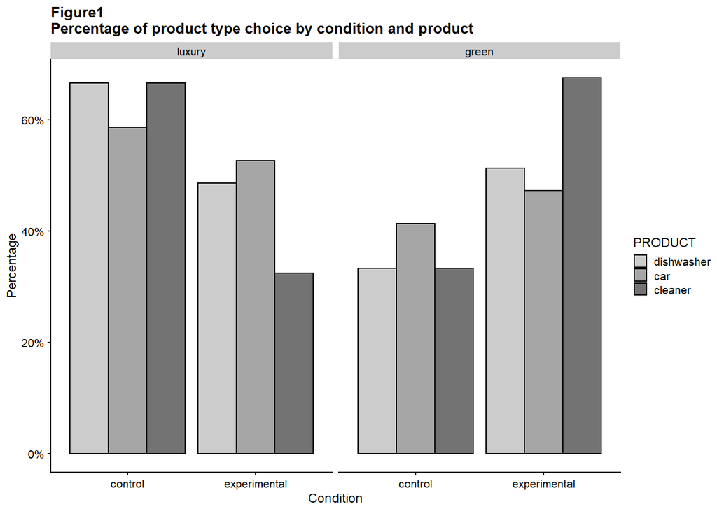

# Discussion

To test whether pro-environmental consumption is driven by status motives, an experiment priming participants for status motives and testing their preference for green or luxury products was conducted, replicating part of the study done by Griskevicius, Tybur and Van den Bergh (2010). Previous studies have linked status motives to green consumption and argued that costly signalling and competitive altruism led to consumers forgoing luxury products for pro-environmental alternatives. Therefore it was expected that participants that had been primed for status would prefer the green option of the presented products (Sexton & Sexton, 2014; Griskevicius et al., 2010).

Indeed, the green dishwasher and cleaner were chosen significantly more often by participants that had been primed for status motives, but the status priming did not have a significant effect on the choice of car. These results suggest that status motives drive pro-environmental consumption regarding some products but not others.  
Griskevicius et al. (2010) found that the green version of the household cleaner, dishwasher and car were chosen more often when participants were primed for status. While Griskevicius et al.’s (2010) results suggest that status motives do indeed drive pro-environmental consumption, the current data suggest that this relationship only applies to certain products or that the effect has been overestimated in the literature (Elliott, 2013; Kennedy & Horne, 2019; Sexton & Sexton, 2014).  
The current results not only deviate from the results in Griskevicius et al.’s (2010) study that was directly replicated, but also from further results of that paper showing that participants were more inclined to opt for the green option when they expected a conspicuous situation. The current data found that status motives influence certain product choices, but no effect on the most conspicuous consumer choice, the car. Griskevicius et al.’s (2010) findings are in line with other research, showing that self-sacrificial, prosocial action may lead to others perceiving an individual as having a higher status (Kohlová & Urban, 2018; Kennedy & Horne, 2019). The current results contrast part of the research into pro-environmental consumption that has shown that making these prosocial acts of consumption conspicuous leads to more green consumption (Aagerup & Nilsson, 2016; Glazer & Konrad, 2008). Sexton & Sexton (2014) argued that the Prius, an environmentally-friendly car, is a conspicuous way of seeking status through green consumption, but our findings interestingly see the smallest effect of status motivation on the choice of car.

This lack of significant difference between how often the green car was chosen by participants in the experimental and control study could have important implications for the theory of competitive altruism (Hardy & Van Vugt, 2006). Forgoing the luxury version of the products presented can be an act of altruism, benefiting the environment and community. Choosing to be altruistic regarding the cleaner and dishwasher, which are rarely on display, while not choosing a green car, which would make the altruism highly visible is not in line with the theory of competitive altruism. According to competitive altruism, participants should have been inclined to choose highly visible green products to show their prosocial behaviour (Hardy & Van Vugt, 2006).  
If these results are interpreted in that way then they contrast with the research by Sexton and Sexton (2014) and Griskevicius et al. (2010). Which argued that pro-environmental consumption would be a means of showing altruism. This effect may explain why green cars are popular in the US despite higher prices. The current data could suggest that costly signalling did have a larger effect on consumers choosing the Prius, as this model is more expensive and that the intent to signal altruism did not have as large an effect as Griskevicius et al. (2010) and Sexton and Sexton (2014) hypothesised.  
Nevertheless, there are other factors that could have caused the lack of significant difference in car choice. This study did not specifically test for the effect on conspicuousness of the product choice or purchase and therefore the implications should be viewed with caution. Participants in the current study had a mean age of 20.9 years and may not have possessed a car, may not have a driver’s licence or no purchasing plans for a vehicle in the near future. Further, participants could also have been influenced by the attitude of their close social contacts towards pro-environmental cars and their normative beliefs about green car consumption (Göckeritz et al., 2009; Salazar et al., 2013). Lastly, it has to be acknowledged that, while the research shows conspicuous consumption to have an effect on whether green products are chosen, conspicuous consumption and status driven consumption are related but separate constructs (Aagerup & Nilsson, 2016; O’Cass & McEwen, 2004).

These findings contrast recent research as to how conspicuousness may influence the choice of products and contrast aspects of the research regarding green consumption. The current results call into questions whether competitive altruism is an appropriate theory to explain green consumption, or whether it only applies to certain product categories. In turn, it also questions whether status motives are as powerful a driver for green consumption as suggested by previous literature and whether status motives only affect green consumer behaviour regarding specific products.

**Limitations and future research**

This study has several limitations, such as the mean age being 20.9 (SD = 2.19), making the sample a narrow age group which may affect how generalisable the findings are to the population. Testing for consumers intentions to choose products may not translate into consumer behaviour and studies involving actual consumer behaviour may have more relevance for marketing and research (Chandon et al., 2005). While this study sought to address how status motives influence green consumption, it does not offer any insight into what roles conspicuous consumption situations, prices and personal variables have.  
Therefore, future research should further investigate how price differences between green products and alternatives affect consumer behaviour and how status motives affect this relationship. Further research should investigate how personal beliefs and normative beliefs interact with status motives to drive pro-environmental consumption and to understand whether pro-environmental behaviour is used to distinguish oneself from the group or to blend in (Bergquist et al., 2019; Elliott, 2013; Göckeritz et al., 2009). Additionally, further research should explore how status motives influence the consumption of pre-used goods, which can be seen as environmentally friendly, in different product categories and to understand what green consumption behaviour is affected by status motives (De Silva et al., 2020). As the literature often draws on costly signalling theory and competitive altruism theory to explain green consumption, further research should investigate how the two constructs may influence each other and contribute to green consumption.

**Conclusion**

This study has added to the literature by replicating the study by Griskevicius et al. (2010) and found differences in results. Status motives did not have a clear effect on pro-environmental consumption in all tested product categories. These findings stand in contrast to previous research that suggested strong links between status motives and green consumption. Previous literature draws on the competitive altruism theory to explain why people engage in altruistic green consumption, which does not explain the present findings. To clarify these differences, further research should focus on the links and how context, personal beliefs and price difference may affect green consumption.

# References

Aagerup, U., & Nilsson, J. (2016). Green consumer behavior: Being good or seeming good? *Journal of Product & Brand Management, 25*(3), 274–284. https://doi.org/10.1108/JPBM-06-2015-0903

Bergquist, M., Nilsson, A., & Ejelöv, E. (2019). Contest-Based and Norm-Based Interventions: (How) Do They Differ in Attitudes, Norms, and Behaviors? *Sustainability, 11*(2), 425. https://doi.org/10.3390/su11020425

Chandon, P., Morwitz, V. G., & Reinartz, W. J. (2005). Do Intentions Really Predict Behavior? Self-Generated Validity Effects in Survey Research. *Journal of Marketing, 69*(2), 1–14. https://doi.org/10.1509/jmkg.69.2.1.60755

De Silva, M., Wang, P., & Kuah, A. T. H. (2020). Why wouldn’t green appeal drive purchase intention? Moderation effects of consumption values in the UK and China. *Journal of Business Research*, S0148296320300229. https://doi.org/10.1016/j.jbusres.2020.01.016

Elliott, R. (2013). The taste for green: The possibilities and dynamics of status differentiation through “green” consumption. *Poetics, 41*(3), 294–322. https://doi.org/10.1016/j.poetic.2013.03.003

Glazer, A., & Konrad, K. A. (2008). A Signaling Explanation for Charity. In R. D. Congleton, K. A. Konrad, & A. L. Hillman (Eds.), *40 Years of Research on Rent Seeking 2* (pp. 713–722). Springer Berlin Heidelberg. https://doi.org/10.1007/978-3-540-79247-5_43

Göckeritz, S., Schultz, P. W., Rendón, T., Cialdini, R. B., Goldstein, N. J., & Griskevicius, V. (2009). Descriptive normative beliefs and conservation behavior: The moderating roles of personal involvement and injunctive normative beliefs. *European Journal of Social Psychology, 40*, 514-523. https://doi.org/10.1002/ejsp.643

Griskevicius, V., Tybur, J. M., & Van den Bergh, B. (2010). Going green to be seen: Status, reputation, and conspicuous conservation. *Journal of Personality and Social Psychology, 98*(3), 392–404. https://doi.org/10.1037/a0017346

32*(10), 1402–1413. https://doi.org/10.1177/0146167206291006

Kennedy, E. H., & Horne, C. (2019). Do Green Behaviors Earn Social Status? *Socius: Sociological Research for a Dynamic World, 5*, 237802311983633. https://doi.org/10.1177/2378023119836330

Kohlová, M. B., & Urban, J. (2018). *Green consumption signals altruism and elevated social status* [Preprint]. PsyArXiv. https://doi.org/10.31234/osf.io/2vgex

O’Cass, A., & McEwen, H. (2004). Exploring consumer status and conspicuous consumption. *Journal of Consumer Behaviour, 4*(1), 25–39. https://doi.org/10.1002/cb.155

Salazar, H. A., Oerlemans, L., & van Stroe-Biezen, S. (2013). Social influence on sustainable consumption: Evidence from a behavioural experiment: Social influence in sustainable consumption. *International Journal of Consumer Studies, 37*(2), 172–180. https://doi.org/10.1111/j.1470-6431.2012.01110.x

Sexton, S. E., & Sexton, A. L. (2014). Conspicuous conservation: The Prius halo and willingness to pay for environmental bona fides. *Journal of Environmental Economics and Management, 67*(3), 303–317. https://doi.org/10.1016/j.jeem.2013.11.004

# Appendix

[figure not shown]

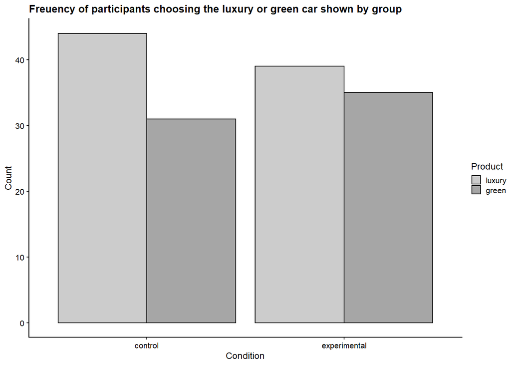

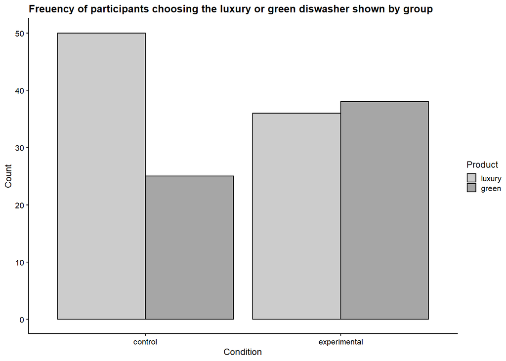

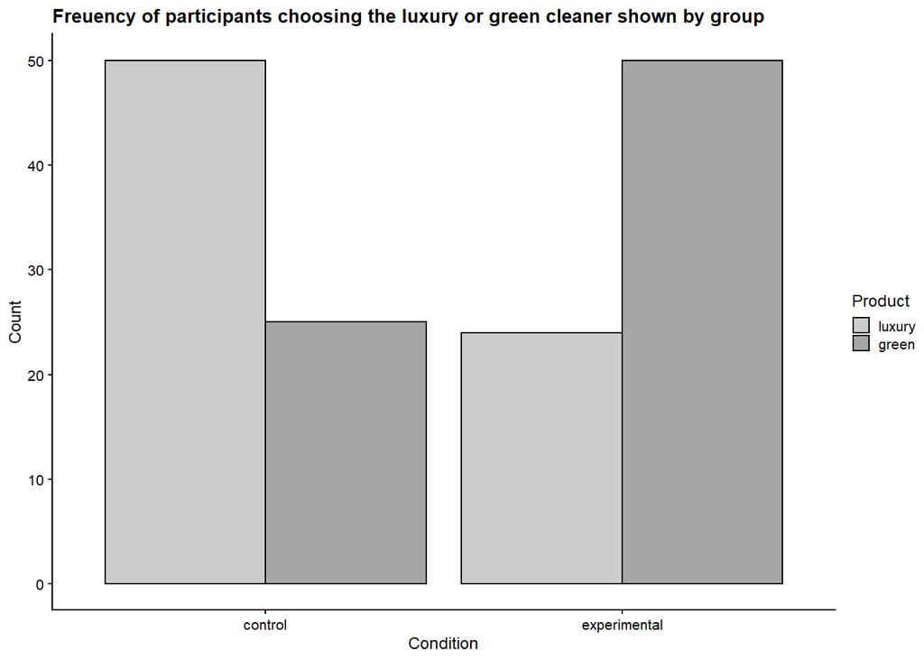